# index

## Introduction

In 2001, Nintendo released [Super Smash Bros. Melee](https://en.wikipedia.org/wiki/Super_Smash_Bros._Melee) for their new GameCube console. Attempting to follow up the success of the original Super Smash Bros. (released on Nintendo 64), Melee is a crossover platform figher featuring 26 characters from Nintendo's other franchises. Melee went on to sell over 7 million copies as the GameCube's best performing game and a competitive scene of players aiming to be the worlds best immediately emerged. A 2013 documentary called [The Smash Brothers](https://en.wikipedia.org/wiki/The_Smash_Brothers) would catapult Melee's scene into the spotlight and establish it as one of esports' biggest games. The community has only grown since then and 2022 has been one of competitive Melee's biggest years.

Competitive Melee is played in a tournament setting where many players show up to a venue for a 1-3 day event and compete for the top spot. Tournaments are run as double-elimination brackets (when you lose twice you're out) where players compete in best-of-3 or best-of-5 sets. A fundamentally grassroots community, most local Melee scenes are defined by one or two weekly local tournaments. Regional tournaments and national tournaments happen every few weeks in most areas but the most important tournaments are known as majors and supermajors: massive tournaments with thousands of dollars in prizes and the opportunity to compete against the world's best. Major results are critical to joining the most important list in Melee: SSBMRank. Published at the end of each year since 2013 (excepting 2020-1 due to COVID-19), SSBMRank asks a panel of Melee's most influential names (commentators, top level players, tournament organizers, and scene figureheads) to rank the best players and compiles the results into a top 100 list published at the end of the year.

This page was written for an undergraduate Data Science assignment to create a tutorial "that walks the reader through the Data Science pipeline". I will be working with the [Smash Player Database](https://github.com/smashdata/ThePlayerDatabase), a collection of nearly all Smash tournament data since ~2015. Panel rankings such as SSBMRank give good insight into the consensus of the scene's leaders - but groups of people have bias and algorithmic ranking systems can come with their own insight. In this tutorial I intend to a) consider a few algorithmic ranking systems, b) compare these ranking systems to each other and themselves, and c) use the best ranking systems to find some interesting stories in Melee. At the time of writing, Ludwig's Scuffed World Tour is the only significant tournament pending for the year and SSBMRank 2022 should be released soon after. Let's see if we can say anything about what those results might look like!

A few quick notes before I dive in to the dataset:

- A highly influential mod known as [Slippi](https://slippi.gg) released an option to play Melee online with rollback netcode (a necessity in the fast paced Fighting Game genre) in 2020 and some tournaments are now online - in keeping with Fighting Game tradition, however, I will only be analyzing offline sets.
- If you're reading this only because you care about Melee, skip to Hypothesis Testing and Data Visualization at the bottom.
- If you're reading this because you care about Data Science (or because you're grading this assignment), you may be vaguely aware of Melee because of recurring drama stemming from continuing Intellectual Property rights disputes between the grassroots scene and Nintendo. I won't be going into this at all in this report - I am much better at data analysis than legal anaylsis ;). Just know that competitive Melee exists in spite of, rather than because of, Nintendo.
- This report will be structured after a somewhat personal reinterpretation of the Data Analysis pipeline:
  1. Data Collection - get everything stored on memory (in rubric as: "Data collection/curation + parsing (if necessary)" and "Data management/representation")
  2. Exploratory Analysis - try some techniques and ask a bunch of questions (in rubric as: "Exploratory Data Analysis")
  3. Hypothesis Testing and Data Visualization - dive deeper into the questions that had interesting answers (in rubric as "Hypothesis testing" and "communication of insights attained")

## Data Collection

As mentioned above, I will be working with the Smash Player Database. This is actually composed of separate databases for each Smash game (at the time of writing only Melee and Ultimate have active scenes) but I will only be looking at Melee data. Before anything else, let's figure out exactly what's contained within this downloaded database:

In this phase of the analysis I will load all the data I'm interested in working with onto memory - both to centralize database calls and reduce potential work if something breaks and to get a sense of all the data available to me. I'll do no analysis of the data beyond reading and commenting on data tables.

External libraries I will use for this section include [`pandas`](https://pypi.org/project/pandas/) for its collection data types (most notably `DataFrame` for tables and `Series` for 1d data) and [`tqdm`](https://pypi.org/project/tqdm/) to show progress indicators.

```python
import sqlite3
import pandas as pd
import warnings
from tqdm import tqdm

warnings.filterwarnings("ignore") # plotting libraries love to spit out nonsense warnings that I don't care about

tqdm.pandas()

sqlite_file = 'melee_player_database/melee_player_database.db'
conn = sqlite3.connect(sqlite_file)

pd.read_sql("SELECT name FROM sqlite_master WHERE type='table';", conn)
```

|  | name |
| --- | --- |
| 0 | tournament_info |
| 1 | sets |
| 2 | players |
| 3 | ranking |
| 4 | ranking_seasons |

This shows separate tables for player data, sets, tournaments, and rankings that I will assemble into separate `pd.DataFrame` objects - these will form the basis for all later analysis. Ranking seasons is an association table that will be summarilly ignored.

I'll start by querying the players table. Character usage is given as a json-formatted `characters` attribute in the original table - I will parse the json and replace the attribute with much more meaningful columns for primary character, secondary character, and number of sets with primary, secondary, and other characters. I'll also create some helper functions to help swap between the unique `player_id` column and the human readable `tag` column to help display results later.

```python
import json
import numpy as np
from collections import Counter

players_query = "SELECT player_id, tag, region, state, country, characters FROM players;" # query to get all data
raw_players_df = pd.read_sql(players_query, conn) # place the query


# character usage is stored as a json - lets get primary character + secondary character data
def parse_char_dict(chars_str):
    char_dict = Counter(json.loads(chars_str))

    if char_dict: # if any character usage is stored at all, get primary
        primary_char, primary_char_uses = char_dict.most_common(1)[0]
        primary_char = primary_char.replace("melee/", "") # we know theyre melee characters already lol
    else:
        primary_char, primary_char_uses = np.NaN, 0


    if len(char_dict.most_common(2)) > 1: # if multiple characters are stored, get secondary
        secondary_char, secondary_char_uses = char_dict.most_common(2)[1]
        secondary_char = secondary_char.replace("melee/", "") # we know theyre melee characters already lol

    else:
        secondary_char, secondary_char_uses = np.NaN, 0

    other_uses = sum(char_dict.values()) - (primary_char_uses + secondary_char_uses)

    return primary_char, primary_char_uses, secondary_char, secondary_char_uses, other_uses


primary_char, primary_char_uses, secondary_char, secondary_char_uses, other_uses = \
    zip(*raw_players_df["characters"].apply(parse_char_dict)) # extract all of these into their own series


# we've got all we need - let's make the players dataframe!
players_df = pd.DataFrame()
players_df["player_id"] = raw_players_df["player_id"].apply(str)
players_df["tag"] = raw_players_df["tag"]
players_df["region"] = raw_players_df["region"]
players_df["state"] = raw_players_df["state"]
players_df["country"] = raw_players_df["country"]
players_df["primary_char"] = primary_char
players_df["primary_char_games"] = primary_char_uses
players_df["secondary_char"] = secondary_char
players_df["secondary_char_games"] = secondary_char_uses
players_df["other_char_games"] = other_uses

# takes an iterable of player_ids, returns generator of respective tags
def get_tags(id_iter):
    for id in id_iter:
        search = players_df[players_df["player_id"] == str(id)]
        yield search.iloc[0]["tag"] if not search.empty else id

# takes an iterable of tags, returns generator of BEST-GUESS ids (remember that multiple players can use the same tag)
def get_ids(tag_iter):
    for tag in tag_iter:
        search = players_df[players_df["tag"] == tag]
        yield search.iloc[0]["player_id"] if not search.empty else tag

players_df.head(n=10)
```

|  | player_id | tag | region | state | country | primary_char | primary_char_games | secondary_char | secondary_char_games | other_char_games |
| --- | --- | --- | --- | --- | --- | --- | --- | --- | --- | --- |
| 0 | 1000 | Mang0 | SoCal | CA | United States | falco | 700 | fox | 505 | 57 |
| 1 | 6126 | Zain | None | VA | United States | marth | 809 | roy | 654 | 197 |
| 2 | 4107 | n0ne | None | ON | Canada | captainfalcon | 1101 | ganondorf | 94 | 22 |
| 3 | 19554 | iBDW | None | NY | United States | fox | 1191 | sheik | 117 | 33 |
| 4 | 15990 | Plup | None | FL | United States | sheik | 635 | fox | 278 | 197 |
| 5 | 1004 | Hungrybox | None | FL | United States | jigglypuff | 3925 | fox | 17 | 33 |
| 6 | 3561 | Ginger | None | MI | United States | falco | 2478 | fox | 129 | 137 |
| 7 | 1028 | Wizzrobe | None | FL | United States | captainfalcon | 756 | NaN | 0 | 0 |
| 8 | 1017 | S2J | SoCal | CA | United States | captainfalcon | 2026 | falco | 115 | 6 |
| 9 | 3357 | Spark | NorCal | CA | United States | sheik | 474 | fox | 10 | 3 |

Next I'll query the tournament results table. As mentioned above, I will only consider offline events. Placements for each tournament are stored in a single json attribute that I will parse and insert into the DataFrame as separate columns for each placing.

Remember that these are double elimination tournaments - Player X appearing above Player Y on a row of this table means "X placed at least as well as Y" and NOT that "X placed better than Y". I'll store the list of places for later too - it will help identify tied tournament placements later.

```python
tourney_query = "SELECT key, cleaned_name, season, entrants, placings FROM tournament_info WHERE online==0;" # query to get all data

raw_tourney_df = pd.read_sql(tourney_query, conn) # place the query

# we'll use this to remember how much each place is worth later
max_places = []

# placings are stored as list of lists [[first_id, 1], [second_id, 2]] etc
# lets extract into separate columns for each placement that we care about!
# remember that these are double elimination tournaments and placement is
# largely ignored in rankings - so all we care about is top 8 placements
def parse_placings(placings_str):
    global max_places

    try:
        placings_list = json.loads(placings_str)
        placings_list = filter(lambda x: type(x[1]) == int, placings_list) # filter duplicate str placements
        placings_list = sorted(placings_list, key=lambda x: x[1] if x[1] > 0 else 10**10) # sort

        ids, places = zip(*placings_list)
        ids = pd.Series(ids).drop_duplicates().to_list()

        if len(places) > len(max_places):
            max_places = places

        return pd.DataFrame([ids])

    except AssertionError:

        return pd.DataFrame([np.NaN])

    except ValueError:

        return pd.DataFrame([np.NaN])


# we've got all we need, let's make the tourney dataframe
tourney_df = pd.concat(raw_tourney_df["placings"].apply(parse_placings).to_list()).reset_index()
tourney_df["key"] = raw_tourney_df["key"]
tourney_df["cleaned_name"] = raw_tourney_df["cleaned_name"]
tourney_df["season"] = raw_tourney_df["season"]
tourney_df["entrants"] = raw_tourney_df["entrants"]

del(tourney_df["index"])

tourney_df = tourney_df[tourney_df["entrants"] > 0] # filter empty tourneys

tourney_df.sort_values("entrants", ascending=False).head().apply(lambda row: [*get_tags(row)])
```

|  | 0 | 1 | 2 | 3 | 4 | 5 | 6 | 7 | 8 | 9 | ... | 2334 | 2335 | 2336 | 2337 | 2338 | 2339 | key | cleaned_name | season | entrants |
| --- | --- | --- | --- | --- | --- | --- | --- | --- | --- | --- | --- | --- | --- | --- | --- | --- | --- | --- | --- | --- | --- |
| 16 | Hungrybox | Armada | Plup | Mang0 | S2J | Mew2King | Westballz | PewPewU | Swedish Delight | Duck | ... | Thingon | NFreak | Medusa | CharlesV | dookdiggity | Spade | evo-2016 | EVO 2016 | 16 | 2360 |
| 144 | Armada | Mang0 | Hungrybox | Axe | SFAT | PPMD | Ice | Nintendude | Mew2King | Plup | ... | NaN | NaN | NaN | NaN | NaN | NaN | genesis-3__melee-singles | GENESIS 3 | 16 | 1828 |
| 62 | Armada | Mang0 | Mew2King | Hungrybox | Leffen | Plup | Westballz | Axe | S2J | ChuDat | ... | NaN | NaN | NaN | NaN | NaN | NaN | genesis-4__melee-singles | GENESIS 4 | 17 | 1703 |
| 15 | Armada | Hungrybox | PPMD | Plup | Leffen | Mang0 | Axe | ChuDat | Ice | PewPewU | ... | NaN | NaN | NaN | NaN | NaN | NaN | evo-2015 | EVO 2015 | 15 | 1676 |
| 128 | Mang0 | Armada | Ice | Mew2King | Hungrybox | SFAT | PewPewU | Wizzrobe | Silent Wolf | The Moon | ... | NaN | NaN | NaN | NaN | NaN | NaN | the-big-house-6__melee-singles | The Big House 6 | 16 | 1562 |

5 rows × 2344 columns

I also want to query the sets table to see more than just overall tournament results! This is the simplest table, requiring no parsing, but does require some SQL knowledge to only pull games associated with offline tournaments.

```python
sets_query = """
SELECT sets.key, sets.tournament_key, sets.winner_id, sets.p1_id, sets.p2_id, sets.p1_score, sets.p2_score, tournament_info.season
FROM sets INNER JOIN tournament_info
    ON sets.tournament_key == tournament_info.key
    WHERE tournament_info.online == 0
""" # query to get all sets from offline tournaments only

sets_df = pd.read_sql(sets_query, conn) # place the query
sets_df["p1_win"] = sets_df["p1_id"] == sets_df["winner_id"] # make a logical p1_wins column
sets_df["winner_id"] = sets_df["winner_id"].apply(str)
sets_df["p1_id"] = sets_df["p1_id"].apply(str)
sets_df["p2_id"] = sets_df["p2_id"].apply(str)

sets_df.head().apply(lambda row: [*get_tags(row)])
```

|  | key | tournament_key | winner_id | p1_id | p2_id | p1_score | p2_score | season | p1_win |
| --- | --- | --- | --- | --- | --- | --- | --- | --- | --- |
| 0 |  | mlg-world-finals-2015 | Hungrybox | Hungrybox | Mew2King | 3 | 1 | 15 | True |
| 1 |  | mlg-world-finals-2015 | Hungrybox | Hungrybox | Axe | 3 | 1 | 15 | True |
| 2 |  | mlg-world-finals-2015 | Hungrybox | Hungrybox | Sami | 3 | 0 | 15 | True |
| 3 |  | mlg-world-finals-2015 | Axe | Axe | Mew2King | 3 | 2 | 15 | True |
| 4 |  | mlg-world-finals-2015 | Hungrybox | Hungrybox | Prince_Abu | 3 | 0 | 15 | True |

Finally, I'll pull all of the official SSBMRank results. Placements are again stored in a json that will need to be parsed into columns.

```python
rankings_query = "SELECT season, by_placing FROM ranking_seasons;" # query to get all data

raw_rankings_df = pd.read_sql(rankings_query, conn) # place the query

def parse_rankings(placing_str):
    rankings = json.loads(placing_str).values()

    return pd.DataFrame([rankings], columns=range(1, 101))


# we've got all we need, lets make the last dataframe!
rankings_df = pd.concat(raw_rankings_df["by_placing"].apply(parse_rankings).to_list()).reset_index()
rankings_df["season"] = raw_rankings_df["season"]

rankings_df.set_index("season", inplace=True)
del(rankings_df["index"])

rankings_df.head().apply(lambda row: [*get_tags(row)])
```

| season | 1 | 2 | 3 | 4 | 5 | 6 | 7 | 8 | 9 | 10 | ... | 91 | 92 | 93 | 94 | 95 | 96 | 97 | 98 | 99 | 100 |
| --- | --- | --- | --- | --- | --- | --- | --- | --- | --- | --- | --- | --- | --- | --- | --- | --- | --- | --- | --- | --- | --- |
| 2015 | Armada | Hungrybox | Leffen | Mang0 | Mew2King | PPMD | Plup | Westballz | Axe | Shroomed | ... | gamerjim | Phil | PorkChops | IB | OkamiBW | Crush | Toph | Bizzarro Flame | Captain Smuckers | DoH |
| 2016 | Armada | Hungrybox | Mang0 | Mew2King | Leffen | Plup | SFAT | Westballz | Axe | Shroomed | ... | Phil | Darrell | Nickemwit | PorkChops | Jflex | Vanity Angel | $mike | Nightmare | 4% | woof woof bark bark |
| 2017 | Hungrybox | Armada | Mang0 | Mew2King | Plup | Leffen | Axe | Wizzrobe | SFAT | S2J | ... | Kaeon | Bobby Frizz | Iceman | L | Nickemwit | moky | Legend | Zealous5000 | Ralph | 2saint |
| 2018 | Hungrybox | Armada | Leffen | Plup | Mang0 | Mew2King | Zain | Wizzrobe | aMSa | Axe | ... | TheRealThing | JOJI | Trulliam | Cob | Iceman | vortex | Magi | nebbii | Morsecode762 | Azel |
| 2019 | Hungrybox | Leffen | Mang0 | Axe | Wizzrobe | Zain | aMSa | Plup | iBDW | Mew2King | ... | Amsah | Rocky | Sharkz | htwa | Kage | Schythed | Panda | Soonsay | TheSWOOPER | Snowy |

5 rows × 100 columns

## Exploratory Analysis

Now that we have all of our relevant data stored on memory lets try out some ranking algorithms and ask questions about what they say! In this phase of the analysis I will be implementing and testing a number of algorithms to rank players for each season. I'll ask a lot of questions but answer them in pretty shallow ways, marking down interesting results to look more closely at in the next phase of analysis.

Before we start I'm making a helper function to narrow down the list of contenders and help reduce computational complexity. I'll create a function to pull all players who placed above a given place at a tournament with a given number of entrants - notably, this is how eligibility for SSBMRank was decided back when the methodology was open.

```python
def top_k_more_than_n_entrants(k, n, season=22, or_win=False):
    tourneys = tourney_df[tourney_df["season"] == season]
    tourneys = tourneys[tourneys["entrants"] >= n]

    places = [tourneys[i] for i in range(k)]
    by_placement = pd.concat(places)

    if or_win:
        winners = tourney_df[tourney_df["season"] == season][0]
        return pd.concat([winners, by_placement]).drop_duplicates().dropna().to_list()
    else:
        return by_placement.drop_duplicates().dropna().to_list()
```

### Winrate

The most intuitive way to rank players is to see how "winning" they are - what percentage of their games do they win? Breaking our data down into seasons, let's look at the winningest players from each season.

```python
def get_winrate(player_id, season=22):
    seasonal_df = sets_df[sets_df["season"] == season]

    p1_results = seasonal_df[seasonal_df["p1_id"] == player_id]["p1_win"]
    p2_results = ~seasonal_df[seasonal_df["p2_id"] == player_id]["p1_win"]
    wins = p1_results.sum() + p2_results.sum()
    played = p1_results.shape[0] + p2_results.shape[0]

    return wins / played

candidate_ids = top_k_more_than_n_entrants(64, 300, season=19)
candidates = players_df[players_df["player_id"].isin(candidate_ids)].copy()
candidates["winrate"] = candidates["player_id"].progress_apply(get_winrate)
candidates.sort_values(by="winrate", ascending=False).head(10)
```

|  | player_id | tag | region | state | country | primary_char | primary_char_games | secondary_char | secondary_char_games | other_char_games | winrate |
| --- | --- | --- | --- | --- | --- | --- | --- | --- | --- | --- | --- |
| 18916 | 51238 | vyn | None | AR | United States | fox | 63 | marth | 51 | 20 | 1.000000 |
| 5445 | 25992 | maXy | None | None | United Kingdom | jigglypuff | 43 | zelda | 9 | 0 | 1.000000 |
| 5830 | 69472 | Jake | None | OH | United States | marth | 69 | sheik | 20 | 2 | 1.000000 |
| 5318 | 21553 | Nicki | None | None | Germany | fox | 354 | iceclimbers | 61 | 14 | 0.989691 |
| 7631 | 5377 | Jah Ridin' | None | None | Switzerland | luigi | 379 | NaN | 0 | 0 | 0.946309 |
| 6190 | 26350 | Cob | None | KY | United States | peach | 219 | bowser | 82 | 32 | 0.928571 |
| 7995 | 40154 | Rick | None | TX | United States | falco | 227 | NaN | 0 | 0 | 0.914894 |
| 22 | 1009 | Colbol | None | GA | United States | fox | 1162 | marth | 34 | 0 | 0.907285 |
| 28564 | 28190 | It's Ok If I Lose | None | None | Belgium | marth | 100 | captainfalcon | 88 | 9 | 0.905882 |
| 24 | 1016 | Fiction | SoCal | CA | United States | falco | 323 | fox | 173 | 0 | 0.896186 |

These don't look like a list of top players at all! What looks to be happening is that players who often attend and win their local tournaments end up with a very high winrate - this does make sense, and is why winrate is a pretty limited metric for ranking. Let's test how well correlated this chart is with SSBMRank for each season.

I will use an external library named [scipy](https://pypi.org/project/scipy/) for this and future p-value calculations.

```python
import scipy.stats as stats

for season, season_ranks in rankings_df.groupby("season"):
    candidate_ids = season_ranks[0:100].iloc[0]
    candidates = players_df[players_df["player_id"].isin(candidate_ids)].copy()

    winrate = candidates["player_id"].apply(get_winrate, season=int(season)-2000).dropna()
    # data is incomplete for 2015, drop unknown winrate

    rho, p_val = stats.spearmanr(range(len(winrate)), winrate)
    print(str(season) + ": rho of", rho, "(p=" + str(p_val) + ")")
```

```
2015: rho of 0.231247678905747 (p=0.02339666895845368)
2016: rho of -0.10658879192183571 (p=0.29119790003589435)
2017: rho of -0.2899304783678737 (p=0.0034337833419486705)
2018: rho of -0.1534970908266835 (p=0.12732803658716071)
2019: rho of -0.174776579320655 (p=0.08199864872006755)
```

I use an external library called [matplotlib](https://pypi.org/project/matplotlib/) and a wrapper library around it called [seaborn](https://pypi.org/project/seaborn/) to help with this and future figure generating.

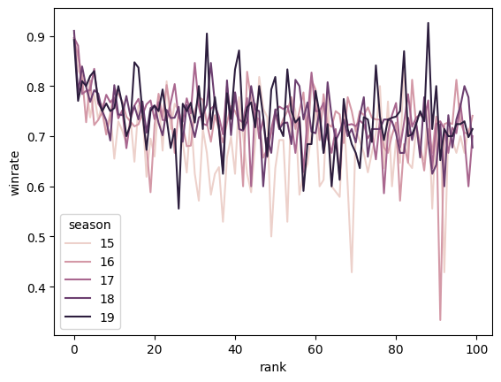

```python
import seaborn as sns
import matplotlib.pyplot as plt

winrate_rankings = {}
for i in range(5):
    top_100 = rankings_df.iloc[i]
    for rank, id in enumerate(top_100):
        winrate_rankings[(i*100) + rank] = [rank, get_winrate(id, season=15+i), 15+i]

winrate_df = pd.DataFrame.from_dict(winrate_rankings, orient="index", columns=["rank", "winrate", "season"])
sns.lineplot(data=winrate_df, x="rank", y="winrate", hue="season");
```

### Glicko-2

Some wins are clearly more impressive than others - what if we could modify winrate to reward impressive wins more and unimpressive wins less? This is the basis for [Glicko-2](http://glicko.net/glicko.html), a rating system widely used in 2 player games such as chess. In keeping with the imprecision of chess terminology, I will also be referring to this as [ELO (the system that Glicko-2 replaced)](https://www.chess.com/terms/elo-rating-chess). I'll also refer to it as MMR (MatchMaking Rating) - this is also not quite the same, but all are used to refer to systems that algorithmically predict how likely a certain player is to beat another one (and all three are rarely used precisely). Let's see what happens if we apply it to Melee.

Instead of rolling my own Glicko-2 implementation, I will use [one available online](https://pypi.org/project/glicko2/).

```python
import glicko2

def update_ranks(set, season_players):
    p1_id, p2_id, p1_win = set["p1_id"], set["p2_id"], set["p1_win"]

    if p1_id not in season_players:
        season_players[p1_id] = glicko2.Player()
    if p2_id not in season_players:
        season_players[p2_id] = glicko2.Player()

    p1, p2 = season_players[p1_id], season_players[p2_id]

    p1.update_player([p2.rating], [p2.rd], [p1_win])
    p2.update_player([p1.rating], [p1.rd], [not p1_win])


season_elo_dfs = {}
elo_ranks = {}
for season, season_sets in sets_df.groupby("season"):
    if season:
        season_players = {}

        season_sets.apply(update_ranks, season_players=season_players, axis=1)
        mmr = pd.Series(season_players).apply(lambda player: player.rating)

        season_df = players_df[players_df["player_id"].isin(season_players)].copy().set_index("player_id")
        season_df["mmr"] = mmr

        mmr_top_100 = season_df.sort_values("mmr", ascending=False).head(100).index.to_list()
        elo_ranks[season] = mmr_top_100

        season_elo_dfs[season] = season_df
        season_elo_dfs[season]["season"] = season


elo_ranks = pd.DataFrame.from_dict(elo_ranks, orient="index")
elo_ranks.apply(lambda row: [*get_tags(row)])
```

|  | 0 | 1 | 2 | 3 | 4 | 5 | 6 | 7 | 8 | 9 | ... | 90 | 91 | 92 | 93 | 94 | 95 | 96 | 97 | 98 | 99 |
| --- | --- | --- | --- | --- | --- | --- | --- | --- | --- | --- | --- | --- | --- | --- | --- | --- | --- | --- | --- | --- | --- |
| 15 | Armada | Leffen | Hungrybox | Mang0 | Overtriforce | Westballz | reaper | PPMD | Ice | Däumling | ... | Eikelmann | Moose | Mittens | silentspectre | Amsah | MIOM \| Juggleguy | Professor Pro | Trail | Azusa | Prof |
| 16 | Hungrybox | Armada | Mang0 | Leffen | Mew2King | Wizzrobe | Plup | Westballz | Swedish Delight | Ice | ... | gamerjim | Kira | OkamiBW | Zanguzen | Mr. Brown | Alex19 | Moose | DJ Nintendo | bËsti | Alox |
| 17 | Armada | Hungrybox | Mew2King | Leffen | SFAT | Mang0 | Plup | ChuDat | Lucky | Axe | ... | Duck | Sixx | Alan | Trulliam | gLory | Franz | vortex | Moose | R2DLiu | XIF |
| 18 | Hungrybox | Plup | Leffen | Armada | Mang0 | Zain | Wizzrobe | Mew2King | SFAT | aMSa | ... | 42nd | Cactuar | Morsecode762 | Nintendude | Captain Smuckers | Drephen | Jake | JohnnyFight | Travioli | Bobby Frizz |
| 19 | Hungrybox | Zain | Mang0 | Wizzrobe | Leffen | Axe | Fiction | iBDW | aMSa | Trif | ... | Timi | dronin | ARMY | TheSWOOPER | Drephen | bobby big ballz | Bimbo | Joyboy | ORLY | Magi |
| 20 | Hungrybox | Fiction | Zain | S2J | Colbol | Soonsay | AbsentPage | Mang0 | Plup | moky | ... | Wevans | billybopeep | bobby big ballz | Davox22 | Drephen | The Moon | TheSWOOPER | Darkatma | Nergal | 23 |
| 21 | Polish | Plup | Leffen | Trif | KJH | FatGoku | Wizzrobe | Zealot | Zain | iBDW | ... | Plagioclase | Joshman | Ice | MirageOnHigh | JohsyJam | Slowking | Aluf | Morsecode762 | Drephen | Kins0 |
| 22 | aMSa | Mang0 | Zain | iBDW | Jmook | Hungrybox | Fiction | Nicki | HBussy | KoDoRiN | ... | HPR | Mekk | Nickemwit | The Champ 2 | DrLobster | Solanum | Doctor Lobster | ALP | The Leaf | Smashdaddy |

8 rows × 100 columns

#### Glicko-2 vs SSBMRank

This looks way more like a top ranking! Let's start off by comparing this ranking to SSBMRank and see how well it matches.

```python
for season, season_ranks in rankings_df.groupby("season"):
    candidate_ids = season_ranks[0:100].iloc[0]
    season_elo = season_elo_dfs[int(season)-2000]["mmr"]

    elo = [ season_elo[id] if id in season_elo else 1500 for id in candidate_ids]
    # incomplete 2015 data strikes again - call unknown rankings average

    rho, p_val = stats.spearmanr(range(len(elo)), elo)
    print(str(season) + ": rho of", rho, "(p=" + str(p_val) + ")")
```

```
2015: rho of -0.5775510819005789 (p=3.158375696641537e-10)
2016: rho of -0.7368016801680167 (p=2.3763902701408092e-18)
2017: rho of -0.8143534353435342 (p=6.843192247444676e-25)
2018: rho of -0.87008700870087 (p=7.152846550942369e-32)
2019: rho of -0.6766396639663965 (p=1.101685367094617e-14)
```

Great! This shows the spearman's rho that we expected - quite close to -1, and with p values small enough that we can reasonably reject the null hypothesis of ELO having a different underlying rank distribution than SSBMRank. Let's take a look closer at ELO distribution.

#### Distribution of Glicko-2

The first thing to look at to understand the distribution of Glicko-2 scores is... well... simply the distribution of Glicko-2 scores! I'll make a density plot of all scores to see if anything pops out.

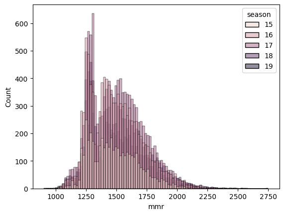

```python
elo_df = pd.concat([season_elo_dfs[season].reset_index() for season in range(15, 20)])
sns.histplot(elo_df, x="mmr", hue="season");
```

Great! This looks like a relatively standard MMR distribution aside from a massive mode (particularly in newer years) at ~1250 of pretty mediocre players. We can also see the growth both in Melee and Melee skill start to emerge. Let's take a closer look at the growth in Melee skill, but this time focus on the top players.

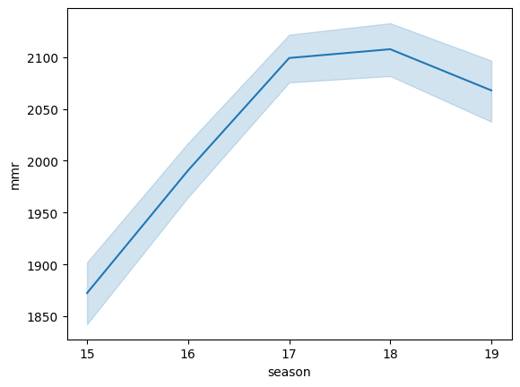

```python
ever_top_100 = pd.concat([rankings_df.loc[str(i+2015)] for i in range(5)]).drop_duplicates().to_list()

ever_top_100_elo = elo_df[elo_df["player_id"].isin(ever_top_100)].copy()
fig = sns.lineplot(ever_top_100_elo, x="season", y="mmr")
fig.set_xticks([15, 16, 17, 18, 19]);
```

Interesting - this suggests that Melee skill peaked just after the games popularity did in 2017-2018. Let's look into this more later. Finally, let's see if we can uncover any pattern in players favored or unfavored by this ranking. I'll start by identifying the players whose ELO is better or worse than their SSBMRank would suggest.

[figure not shown]

```python
even, better, worse = [], [], []


for season, season_ranks in rankings_df.groupby("season"):
    candidate_ids = season_ranks[0:100].iloc[0]
    season_elo = season_elo_dfs[int(season)-2000]["mmr"]

    elo = [ season_elo[id] if id in season_elo else 1500 for id in candidate_ids]
    elo_rank = pd.Series(elo).rank(ascending=False)
    deltas = elo_rank - range(1, len(elo_rank) + 1)

    for player, delta in zip(candidate_ids, deltas):
        if delta > 5:
            better.append(player)
        elif delta < -5:
            worse.append(player)
        else:
            even.append(player)

elo_even_df = players_df[players_df["player_id"].isin(even)].copy()
elo_even_df["delta"] = "even"

elo_better_df = players_df[players_df["player_id"].isin(better)].copy()
elo_better_df["delta"] = "better"

elo_worse_df = players_df[players_df["player_id"].isin(worse)].copy()
elo_worse_df["delta"] = "worse"

elo_delta_df = pd.concat([elo_even_df, elo_better_df, elo_worse_df]).reset_index()

delta_plot = sns.catplot(elo_delta_df, y="primary_char", hue="delta", s=5, kind="swarm")
```

This figure doesn't suggest any that Glicko-2 underrates or overrates any character vs SSBMRank - I'll do a more rigorous analysis of characters in SSBMRank later on.

### Glicko-2 Trained on Tournament Results

The Glicko-2 results looked quite promising - but don't include any sort of reward for winning or placing well at tournaments! This is often the most important factor publically discussed by SSBMRank panelists so let's try making a system to rate players by tournament placing. Since Glicko-2 has already proven itself, I'll try using it again - this time counting a win as "outplacing someone in a tournament" and a loss as... not... doing that?

```python
def update_ranks_tourney(tourney, season_players):
    players = pd.Series(tourney[0:2340]).dropna().to_list()
    rankings = max_places[:len(players)]

    for player in players:
        if player not in season_players:
            season_players[player] = glicko2.Player(vol=.0001)

    ratings = [season_players[player].rating for player in players]
    rds = [season_players[player].rd for player in players]

    for i, player in enumerate(players):
        player_ratings = ratings[:i] + (ratings[i+1:] if i+1 < len(players) else [])
        player_rds = rds[:i] + (rds[i+1:] if i+1 < len(rds) else [])

        player_rank = rankings[i]
        player_results = [int(player_rank <= rank) for rank in rankings]
        del player_results[i]

        season_players[player].update_player(player_ratings, player_rds, player_results)

season_tourney_elo_dfs = {}
tourney_elo_ranks = {}
for season, season_tourneys in tourney_df.groupby("season"):
    if season:
        season_players = {}

        season_tourneys.apply(update_ranks_tourney, season_players=season_players, axis=1)
        mmr = pd.Series(season_players).apply(lambda player: player.rating)

        season_df = players_df[players_df["player_id"].isin(season_players)].copy().set_index("player_id")
        season_df["mmr"] = mmr

        mmr_top_100 = season_df.sort_values("mmr", ascending=False).head(100).index.to_list()
        tourney_elo_ranks[season] = mmr_top_100

        season_tourney_elo_dfs[season] = season_df
        season_tourney_elo_dfs[season]["season"] = season

tourney_elo_ranks = pd.DataFrame.from_dict(tourney_elo_ranks, orient="index")
tourney_elo_ranks.apply(lambda row: [*get_tags(row)])
```

|  | 0 | 1 | 2 | 3 | 4 | 5 | 6 | 7 | 8 | 9 | ... | 90 | 91 | 92 | 93 | 94 | 95 | 96 | 97 | 98 | 99 |
| --- | --- | --- | --- | --- | --- | --- | --- | --- | --- | --- | --- | --- | --- | --- | --- | --- | --- | --- | --- | --- | --- |
| 15 | Mang0 | Mew2King | Armada | Shroomed | Ice | Axe | Plup | Santi | Langley Trifasia | Delphiki | ... | Scar | Wizzrobe | Kira | AdamDutchie | Salevits | Reno | FA0 | Azen zagenite | [62-bit] vish | Okamibw |
| 16 | Valdo | Rael | PPMD | Ken | Armada | Mew2King | Hungrybox | Zhu | Shroomed | KJH | ... | Wobbles | Zgetto | JAVI | Trif | lovage805 | Luigi Ka-Master | Minty | Qerb | Husband | aMSa |
| 17 | Hungrybox | Darrell | Morrito 2 | Leffen | Yoshi | Machiavelli | baka4moe | Plup | MOP | Shroomed | ... | Gas$ | Vudujin | Kage | voorhese | Darrell | silentspectre | Nickemwit | Captain Swerg | Espeon | C15 |
| 18 | itspancaketime | Abate | lloD | Hungrybox | Prince F. Abu | Vitus | Zain | Bananas | SFAT | Lucky | ... | Snowy | Nintendude | Ice | Fiction | 42nd | Rymo | Frenzy | Vinodh | Amsah | Rush |
| 19 | Santi | 404Cray | JOAT Guy | hdhr | Hungrybox | ckyulmiqnudaetr | n0ne | Jake | Cami | Forrest | ... | Cobb | Zbert | Dubltu | SAUS | Fishbait | 5'10 | Jflex | Arc | ilovebagelz | JWick |
| 20 | Nergal | Grab | Fiction | Radiante | Jesse | null | ARMY | Albert | Colbol | SmallHandsBrian | ... | Jerry | Joyboy | Smashdaddy | Tubby Lumpkins | A Rookie | S2J | MegaXmas | Darling | Ryan Ford | Frenzy |
| 21 | Kalamazhu | Leffen | Panda | Wally | Zain | Polish | Dash | Ossify | Mang0 | Smashdaddy | ... | DrLobster | Travioli | JST | Ad | Palpa | bibbit | Brazmonkey | Semi | Waldo Pickles | Swift |
| 22 | Ossify | HBussy | Mang0 | Phil | Quaff | Touma | Maximyss | Beerman | Lucky | sillipro | ... | bluezaft | Danny Phantom | Rose | Evan | Ethan | It's Ok If I Lose | Slowking | null | Chem | Lexor |

8 rows × 100 columns

This is reminiscent of the winrate ranker - these names don't look like any sort of top player list I've ever seen! That's deeply unsurprising - Glicko-2 is designed for 2-player games and this usage feels a bit strange. Let's compare its output to the SSBMRank and see if theres any correlation.

```python
for season, season_ranks in rankings_df.groupby("season"):
    candidate_ids = season_ranks[0:100].iloc[0]
    season_elo = season_tourney_elo_dfs[int(season)-2000]["mmr"]

    elo = [ season_elo[id] if id in season_elo else 1500 for id in candidate_ids]
    # incomplete 2015 data strikes again - call unknown rankings average

    rho, p_val = stats.spearmanr(range(len(elo)), elo)
    print(str(season) + ": rho of", rho, "(p=" + str(p_val) + ")")
```

```
2015: rho of -0.4178577396320774 (p=1.5207226934502996e-05)
2016: rho of -0.5396196752091034 (p=6.904079476304612e-09)
2017: rho of -0.6702190219021902 (p=2.414238824782617e-14)
2018: rho of -0.46222622262226215 (p=1.2903564550217241e-06)
2019: rho of -0.25269726972697265 (p=0.011196319513537088)
```

Interestingly, despite the relatively poor rank correlation (around or below -0.5), it's quite easy to reject the null hypothesis of this ELO not sharing an underlying rank distribution with SSBMRank. Despite that, I think we can do better - the Glicko-2 Spearman's rho values were way closer to -1!

### Points Gained by Tourney Placements

Glicko-2 seems imperfect for rewarding tournament placements so let's try a more normal system. One very common system for rewarding tournament systems is to assign each tournament a total point value based on size and then give players points based on their placements. To avoid rewarding players for showing up and winning the same small tournament over and over, many such systems also cap the number of tournaments a player can be rewarded for (these are often referred to as markers). I'll assign each tournament a point value based on the number of entrants - first let's look at the distribution!

This "normal" system is heavily inspired by the points system used in the [American Parliamentary Debate Association standings for Player of the Year / Team of the Year](http://results.apda.online). It shares a passing resemblence to, but is MUCH less complex than, a ranking system used in Super Smash Brothers Ultimate (Melee's sequel's sequel's sequel) known as OrionRank. (I know the wiki reports a different methodology for OrionRank - it's [been changed](https://docs.google.com/document/d/103D0dEn3GkBSrbKE5BEr8Kmwl9OdTTBD-LSziFU8Hec/edit), the wiki is just out of data :P).

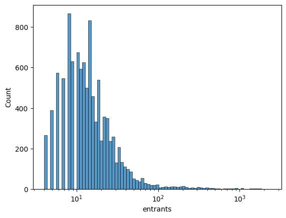

```python
sns.histplot(tourney_df, x="entrants", log_scale=True);
```

Looking at this chart (and [this one](https://liquipedia.net/smash/Major_Tournaments/Melee)) we can make three categories

We'll also only count a players 5 best placings, making 100 a perfect score.

Let's look at tournaments from this year to match up:

```python
def grade_size(tourney):
    if tourney["entrants"] > 250:
        return "major"
    elif tourney["entrants"] > 100:
        return "regional"
    else:
        return "local"

tourney_df["grade"] = tourney_df.apply(grade_size, axis=1)
tourney_df[(tourney_df["season"] == 22)]["grade"].value_counts()
```

```
local       7402
regional      38
major         13
Name: grade, dtype: int64
```

This looks about right! This doesn't take into account invitationals, as those tend to have smaller entrants - I'm okay with this though, as rankings in a grassroots community should probably be based on open tournaments anyway.

Now let's actually generate tournament points for everyone who made at least top 8 at a regional or won a local:

```python
def get_tourney_points(player_id, season=22):
    seasonal_df = tourney_df[tourney_df["season"] == season]
    majors = seasonal_df[seasonal_df["grade"] == "major"]
    regionals = seasonal_df[seasonal_df["grade"] == "regional"]
    locals = seasonal_df[seasonal_df["grade"] == "locals"]

    major_wins = sum(majors[0] == player_id)
    major_podia = sum([sum(majors[i] == player_id) for i in range(1, 8)])

    regional_wins = sum(regionals[0] == player_id)
    regional_podia = sum([sum(regionals[i] == player_id) for i in range(1, 8)])

    local_wins = sum(locals[0] == player_id)

    markers = [20 for _i in range(major_wins)] + [10 for _i in range(major_podia)] + \
              [10 for _i in range(regional_wins)] + [5 for _i in range(regional_podia)] + \
              [5 for _i in range(local_wins)]

    if len(markers) <= 5:
        return sum(markers)
    else:
        return sum(markers[:5])

season_tourney_point_dfs = {}
for season in tqdm(range(15, 20)):
    candidate_ids = top_k_more_than_n_entrants(8, 100, season=season, or_win=True)
    season_tourney_points_df = players_df[players_df["player_id"].isin(candidate_ids)].copy()

    season_tourney_points_df["tourney_points"] = \
        season_tourney_points_df["player_id"].apply(get_tourney_points, season=season)

    season_tourney_point_dfs[season] = season_tourney_points_df.set_index("player_id")
    season_tourney_point_dfs[season]["season"] = season

tourney_point_df = pd.concat([season_tourney_point_dfs[season].reset_index() for season in range(15, 20)])
tourney_point_df.sort_values("tourney_points", ascending=False).head()
```

|  | player_id | tag | region | state | country | primary_char | primary_char_games | secondary_char | secondary_char_games | other_char_games | tourney_points | season |
| --- | --- | --- | --- | --- | --- | --- | --- | --- | --- | --- | --- | --- |
| 4 | 1004 | Hungrybox | None | FL | United States | jigglypuff | 3925 | fox | 17 | 33 | 100 | 18 |
| 5 | 1004 | Hungrybox | None | FL | United States | jigglypuff | 3925 | fox | 17 | 33 | 100 | 17 |
| 5 | 1004 | Hungrybox | None | FL | United States | jigglypuff | 3925 | fox | 17 | 33 | 100 | 19 |
| 22 | 6189 | Armada |  |  | Sweden | peach | 405 | fox | 278 | 1 | 90 | 16 |
| 3 | 1004 | Hungrybox | None | FL | United States | jigglypuff | 3925 | fox | 17 | 33 | 90 | 16 |

Wow, maybe Hungrybox really is the GOAT - the only person to have had a perfect year, and he did it three years in a row. Let's compare these rankings to SSBMRank:

```python
for season, season_ranks in rankings_df.groupby("season"):
    candidate_ids = season_ranks[0:100].iloc[0]
    season_rankings = season_tourney_point_dfs[int(season)-2000]["tourney_points"]

    points = [ season_rankings[id] if id in season_rankings else 0 for id in candidate_ids]

    rho, p_val = stats.spearmanr(range(len(points)), points)
    print(str(season) + ": rho of", rho, "(p=" + str(p_val) + ")")
```

```
2015: rho of -0.6047927954800172 (p=2.6688528225339622e-11)
2016: rho of -0.6238874213232138 (p=4.086549400166843e-12)
2017: rho of -0.7508725097539414 (p=2.3468587212401546e-19)
2018: rho of -0.7992776664947127 (p=2.123732170387609e-23)
2019: rho of -0.7259842944370157 (p=1.277259780206535e-17)
```

As predicted, this correlates much better with SSBMRank than our attempt at abusing the Glicko-2 system! Let's look at how these tournament points are distributed next.

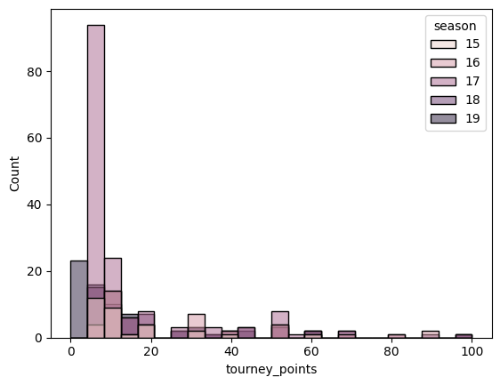

```python
sns.histplot(tourney_point_df, x="tourney_points", hue="season");
```

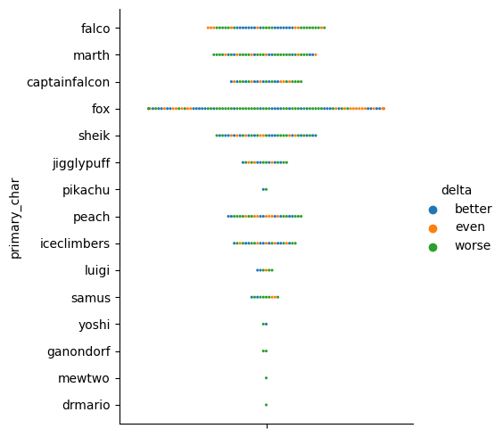

```python
even, better, worse = [], [], []

for season, season_ranks in rankings_df.groupby("season"):
    candidate_ids = season_ranks[0:100].iloc[0]
    season_points = season_tourney_point_dfs[int(season)-2000]["tourney_points"]

    points = [ season_points[id] if id in season_points else 0 for id in candidate_ids]
    points_rank = pd.Series(elo).rank(ascending=False)

    deltas = points_rank - range(1, len(points_rank) + 1)

    for player, delta in zip(candidate_ids, deltas):
        if delta > 5:
            better.append(player) # placed better on SSBMRank than TourneyPoints
        elif delta < -5:
            worse.append(player) # placed worse on SSBMRank than TourneyPoints
        else:
            even.append(player)

points_even_df = players_df[players_df["player_id"].isin(even)].copy()
points_even_df["delta"] = "even"

points_better_df = players_df[players_df["player_id"].isin(better)].copy()
points_better_df["delta"] = "better"

points_worse_df = players_df[players_df["player_id"].isin(worse)].copy()
points_worse_df["delta"] = "worse"

points_delta_df = pd.concat([points_better_df, points_even_df, points_worse_df]).reset_index()

delta_plot = sns.catplot(points_delta_df, y="primary_char", hue="delta", s=5, kind="swarm")
```

Wow, this really seems to affect fox - he looks to have much better results in Tourney Points than SSBMRank! Let's look into that further.

## Hypothesis Testing and Data Visualization

For this phase of the analysis, I will answer a number of practical questions with some degree of certainty. Unlike the last phase, which focused on coming up with questions, this phase will give meaningful and understandable answers to a short list of interesting quesions:

- In our last step, we marked two things down as being worth revisiting later:
  1. Is ELO of top players dropping?
  2. I noticed Fox performs better in Tourney Points ranking than SSBMRank - Can I explain what is happening?
- So far, we've only been analyzing games from 2015-2019 as those are the games with associated SSBMRanks. Now that we've picked our two favorite ranking systems(Glicko-2 and Tourney Points), let's also take a look at this years competition!
  3. What will character composition of this year's Top 100 look like?
  4. Word on the street has it that this year is closer than usual - is this true?

### Is Top Player Skill Dropping?

As mentioned above, the Glicko-2 ratings for top players appear to have dropped off in recent years. Let's begin by making a new plot to look at ELO distribution of top 100 players for each season.

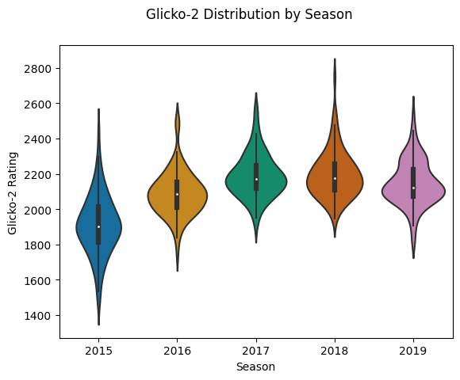

```python
season_top_100s = {}
for season in range(2015, 2020):
    season_top_100 = rankings_df.loc[str(season)]
    season_elo_df = elo_df[elo_df["season"] == season-2000]
    season_top_100_elo = season_elo_df[season_elo_df["player_id"].isin(season_top_100)].copy()

    season_top_100s[season] = season_top_100_elo

season_top_100s = pd.concat(season_top_100s)

fig, ax = plt.subplots(1, 1)

sns.violinplot(season_top_100s, y="mmr", x="season", palette="colorblind", ax=ax)

fig.suptitle("Glicko-2 Distribution by Season")
ax.set_xlabel("Season")
ax.set_xticklabels([2015, 2016, 2017, 2018, 2019])
ax.set_ylabel("Glicko-2 Rating");
```

This is clearer than the last figure and it really does look like top 100 player ELOs are worse in 2019 than they were in 2018. Before we move on, let's confirm this visual intuition with a hypothesis test. We'll compare the 2018 SSBMRank ELOs to the 2019 SSBMRank ELOS with a null hypothesis that they share a population mean (equivalently, that top100 players were exactly as good in 2018 as 2019).

```python
season_18_top_100 = season_top_100s.loc[2018]["mmr"]
season_19_top_100 = season_top_100s.loc[2019]["mmr"]

t_stat, p_val = stats.ttest_ind(season_18_top_100, season_19_top_100)

print("These distributions have a t-stat of", t_stat, "(p="+str(p_val)+")")
```

```
These distributions have a t-stat of 2.6261855855899916 (p=0.009309834509149725)
```

This p-value is below .01 - low enough for me to confidently reject the null hypothesis and say that 2019s top players really did have a lower ELO than 2018s top players. Importantly, this does NOT mean that top player skill fell - Glicko-2 only makes sense within a system of players, so this says something more along the lines of "the gap between top players and average ones fell between 2018 and 2019". I would be most likely to blame this on an increase in average player skill as one of Melee's biggest booms came to an end and players had been playing the game for a longer time.

### Why Do Foxes Get More Tournament Points?

(Note: If you've never played Melee, it's worth noting that Fox is a unique character as the uncontested best in the game - agreed upon since the 8th official tier list released in 2006. Fox is also Melee's most iconic character, with his special move "reflector" - known by fans as "shine" - generating a blue hexagon that is the primary symbol of Melee. Also, if you've never played Melee, [now's a great time to start!](https://blippi.gg))

Another oddity I noticed earlier was that Foxes seem to do better in Tournament Point rankings than SSBMRank - let's generate a plot confirming that suspicion.

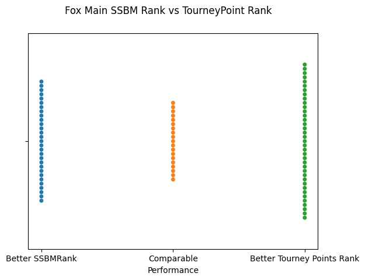

```python
fox_df = points_delta_df[points_delta_df["primary_char"] == "fox"]

fig, ax = plt.subplots(1, 1)

sns.swarmplot(fox_df, x="delta", hue="delta", ax=ax)

fig.suptitle("Fox Main SSBM Rank vs TourneyPoint Rank")
ax.set_xlabel("Performance")
ax.set_xticklabels(["Better SSBMRank", "Comparable", "Better Tourney Points Rank"])
ax.get_legend().remove()
```

Huh, maybe this isn't as real as I though it was. Let's run a hypothesis test to see if Fox performance actually looks worse - the null hypothesis will be that Fox mains rank exactly as high in SSBMRank as Tourney Points Ranking.

```python
def is_fox_main(player_id):
    char = players_df[players_df["player_id"] == player_id].iloc[0]["primary_char"]

    return char == "fox"


for season, season_ranks in rankings_df.groupby("season"):
    candidate_ids = season_ranks[0:100].iloc[0]
    season_rankings = season_tourney_point_dfs[int(season)-2000]["tourney_points"]

    all_points = [ season_rankings[id] if id in season_rankings else 0 for id in candidate_ids]
    all_ranks = pd.Series(all_points).rank(ascending=False)
    all_indices = pd.Series(range(1, 101))

    fox_mains = [is_fox_main(player) for player in candidate_ids]

    fox_ranks = all_ranks[fox_mains]
    fox_indices = all_indices[fox_mains]

    t_stat, p_val = stats.ttest_ind(fox_ranks, fox_indices)
    print("These distributions have a t-stat of", t_stat, "(p="+str(p_val)+")")
```

```
These distributions have a t-stat of 0.5865678704313354 (p=0.560361660802856)
These distributions have a t-stat of 0.6573737414780649 (p=0.513732991242952)
These distributions have a t-stat of -0.15555746798140316 (p=0.8768566448038743)
These distributions have a t-stat of -0.047220807070965744 (p=0.9625114538157872)
These distributions have a t-stat of -0.1637058691889304 (p=0.8705973225491817)
```

Whelp, I guess I misread the original figure :P. These p-values are incredibly high - it would be quite silly to reject the null hypothesis, so it seems like Fox mains are ranked more or less the same whether by SSBMRank or Tourney Points ranking.

### What Will Top 100 Look Like This Year?

Finally I'm getting to the part we've all been waiting for - what will this year's rankings look like? Let's look at the top 100 ELO and tourney points tables. I'm not going to really answer a statistical question here - just show what the year to date rankings look like in terms of top 100 names and primary characters. Time will tell how close these predictions are to the year's rankings!

```python
candidate_ids = top_k_more_than_n_entrants(8, 100, season=22, or_win=True)

ytd_tourney_points_df = players_df[players_df["player_id"].isin(candidate_ids)].copy()
ytd_tourney_points_df["tourney_points"] = ytd_tourney_points_df["player_id"].progress_apply(get_tourney_points, season=22)
ytd_tourney_points_df = ytd_tourney_points_df.sort_values("tourney_points", ascending=False).reset_index()

ytd_elo_df = season_elo_dfs[22].sort_values("mmr", ascending=False).head(100)

potential = pd.DataFrame()
potential["Glicko-2"] = ytd_elo_df.index
potential["TourneyPoints"] = ytd_tourney_points_df["player_id"].reset_index()["player_id"]

with pd.option_context('display.max_rows', None):
    print(potential.apply(lambda row: [*get_tags(row)]))
```

```
             Glicko-2     TourneyPoints
0                aMSa              Zain
1               Mang0              aMSa
2                Zain             Mang0
3                iBDW         Hungrybox
4               Jmook              iBDW
5           Hungrybox           Fiction
6             Fiction             Jmook
7               Nicki           KoDoRiN
8              HBussy            Leffen
9             KoDoRiN              moky
10               SFOP               Axe
11               Zamu            Skerzo
12               SluG             Krudo
13             Leffen              Aklo
```

[output cut: 86 more lines]

These lists are very interesting all by themselves if you follow Melee so I'm printing the whole thing! Especially of note is that the top 7 is the same for both lists and more or less the same top 6 as everyone is expecting + fiction, but the next tier of players looks very different!

Let's breakdown main characters for each list as well.

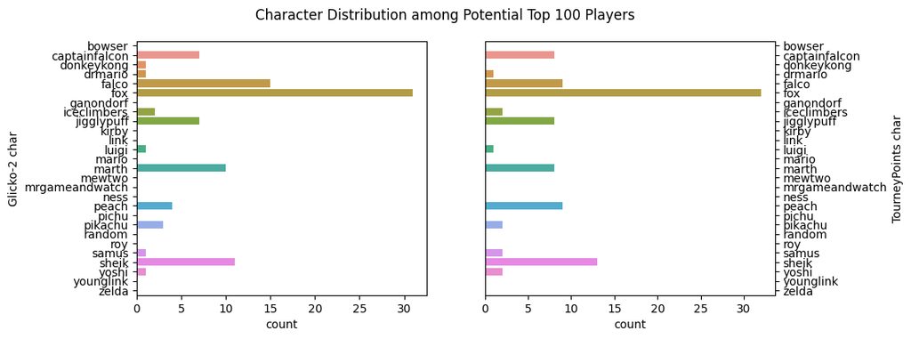

```python
all_chars = players_df["primary_char"].drop_duplicates().dropna().sort_values().to_list()

def get_main(player_id):
    matches = players_df[players_df["player_id"] == player_id]

    char = matches.iloc[0]["primary_char"] if len(matches) else np.NaN

    return char

potential["Glicko-2 char"] = potential["Glicko-2"].apply(get_main)
potential["TourneyPoints char"] = potential["TourneyPoints"].apply(get_main)

fig, ax = plt.subplots(1, 2, figsize=(10, 4))

sns.countplot(potential, y="Glicko-2 char", order=all_chars, ax=ax[0])
sns.countplot(potential, y="TourneyPoints char", order=all_chars, ax=ax[1], )

ax[1].yaxis.set_label_position("right")
ax[1].yaxis.tick_right()
fig.suptitle("Character Distribution among Potential Top 100 Players");
```

There are a few interesting things to note here for fans of the game - spacies (that's Fox and Falco) dominate, as usual, but Marth, Sheik, and Captain Falcon put up fair fights. Compare this with past character distributions:

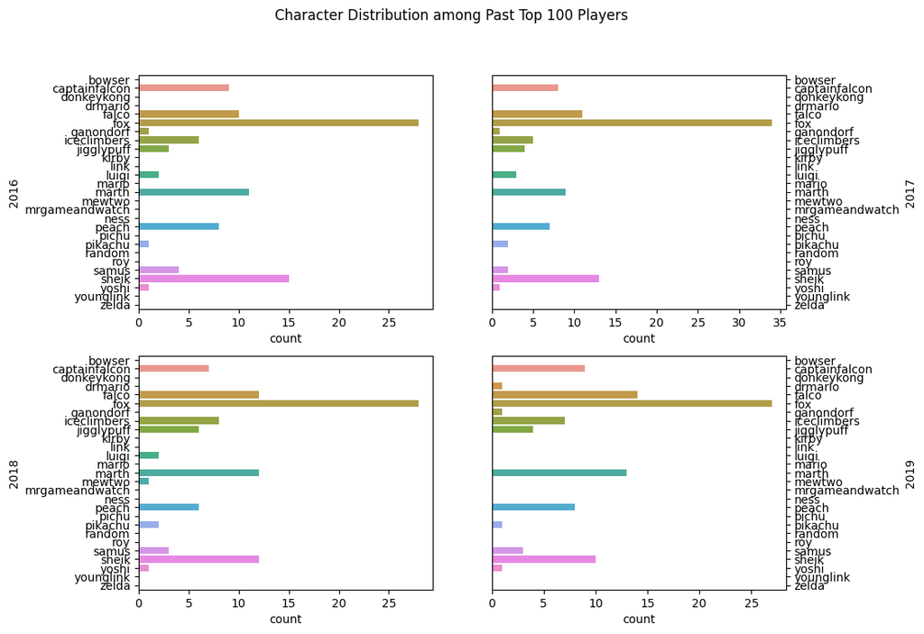

```python
ranked_chars = [rankings_df.iloc[i].apply(get_main) for i in range(5)]

fig, ax = plt.subplots(2, 2, figsize=(10, 8))

for i in range(4):
    sns.countplot(y=ranked_chars[i+1], order=all_chars, ax=ax[i//2][i%2])

ax[0][1].yaxis.set_label_position("right")
ax[0][1].yaxis.tick_right()
ax[1][1].yaxis.set_label_position("right")
ax[1][1].yaxis.tick_right()

fig.suptitle("Character Distribution among Past Top 100 Players");
```

Character composition of the Top 100 should look more or less the same as usual this year if our custom ranking systems hold!

### Is This Year Actually More Competitive?

The last major question I want to answer is whether this year was actually more competitive at the very top than past years. Panelists are known to rarely value head-to-head results as much as tournament placings so we'll calculate Tourney Point differences between top five players for each past year. Once we have that it should be easy to compare it against this year's standings and see if the difference in competition is actually visible.

```python
top_5_tp_vals = []

for season in range(15, 20):
    tp_top_5 = tourney_point_df[tourney_point_df["season"] == season].sort_values("tourney_points", ascending=False).head(5)

    top_5_tp_vals.append(tp_top_5["tourney_points"].to_list())
    print(2000+season, np.var(tp_top_5["tourney_points"]))

print(2022, np.var(ytd_tourney_points_df.sort_values("tourney_points", ascending=False).head()["tourney_points"]))
```

```
2015 184.0
2016 136.0
2017 184.0
2018 216.0
2019 344.0
2022 56.0
```

Woah - that's a massive difference! The average variance in tourney points lies somewhere around 200, but this year is 56. Samples of dimension 5 are unlikely to provide enough `n` for a meaningful hypothesis test, but let's try it anyway! We'll test two null hypotheses - the first being that 2015-2019 rankings have the same underlying variance, and the second being that 2015-2019 and 2022 have the same underlying variance.

```python
_stat, p = stats.levene(*top_5_tp_vals)

print("The probability of a levene stat at least as strong as this for 2015-2019 stats with the same variance is:", p)

_stat, p = stats.levene(*top_5_tp_vals, ytd_tourney_points_df.sort_values("tourney_points", ascending=False).head()["tourney_points"].to_list())
print("The probability of a levene stat at least as strong as this for 2015-2019 and 2022 stats with the same variance is:", p)
```

```
The probability of a levene stat at least as strong as this for 2015-2019 stats with the same variance is: 0.9970132556861661
The probability of a levene stat at least as strong as this for 2015-2019 and 2022 stats with the same variance is: 0.969135737870656
```

As expected, we don't have enough evidence to solidly reject the null hypothesis and suggest that anything real has changed here - a SSBMRank this close, while novel, falls within the bounds we expect to occasionally see due to random chance. Regardless of that fact, this year *was* still much closer than all previous years when it comes to tournament results - just not enough to suggest that the underlying variability of the player skill causing those tournament results has changed.

## Conclusion

2022 marked the return of massive offline Melee tournaments and a renewed excitement surrounding the years SSBMRank. I've introduced two algorithmic alternatives to SSBMRank that also attempt to rank players based on the year's performance, one Glicko-2 based system that trains on set results and one Marker based system that trains on tournament results. While both of these metrics rank players based on the same underlying characteristics as SSBMRank (at least, there is statistically significant evidence of highly correlated ranks), neither one is particularly effective at predicting the SSBMRank wholesale. Despite this, these rankings delivered a few major insights:

- peak ELO, or how likely a top player is to beat an average player, has fallen since Melee's peak
- this year's competition at the top really is much closer *in results* than any year past - although there's not enough to reject the possibility that it's because of random chance rather than the top players being closer *in skill* than before

In addition, I've provided a couple of interesting tables / figures to help understand what this years SSBMRank might look like:

- the top 100 players of the year by Glicko-2 rating (potential ranked players)
- the top 100 players who have placed well enough at tournaments to earn a Tournament Points rating for this year (likely ranked players)
- main character composition of these potential ranked players + character compositions of past SSBMRanks to compare